# Untitled

Mike Johnson

5/6/2022

# For notes

non-api functions used glimpse, filter, inner_join, select geom_sf, geom_histogram, read_sf (with vsi)

topics - tables to spatial, spatial to table (st_drop_geometry) - projected vs geographic CRS - mapping - I/O from APIs and remote files - Spatial predicates/filters

# Impact of Dams on Streamflow

## AWRA 2022

### R and Python Tools for Geospatial Water Applications

The primary goal of this hands-on tutorial is to introduce a handful of geospatial web services for conducting scientific studies. For this purpose, we’re going to take a look at the effects of building dams on streamflows. Here are some example peer-reviewed papers on this topic.

- https://doi.org/10.5194/hess-17-3189-2013
- https://doi.org/10.1002/2017WR020871

We set the area of interest (AOI) for this study to Texas and study dams that have been built in the 1995-2005 period.

# Streamflow Gauges

```r
library(sf)             # vector data
library(terra)          # raster data
library(dplyr)          # data manipulation
library(dataRetrieval)  # USGS data access
```

```r
library(ggplot2)        # data visualization
```

First, we use the National Water Information System (NWIS) service to check streamflow data availability in our AOI, Texas, and 10 years before and after the period of our study, i.e., the 1985-2015 period.

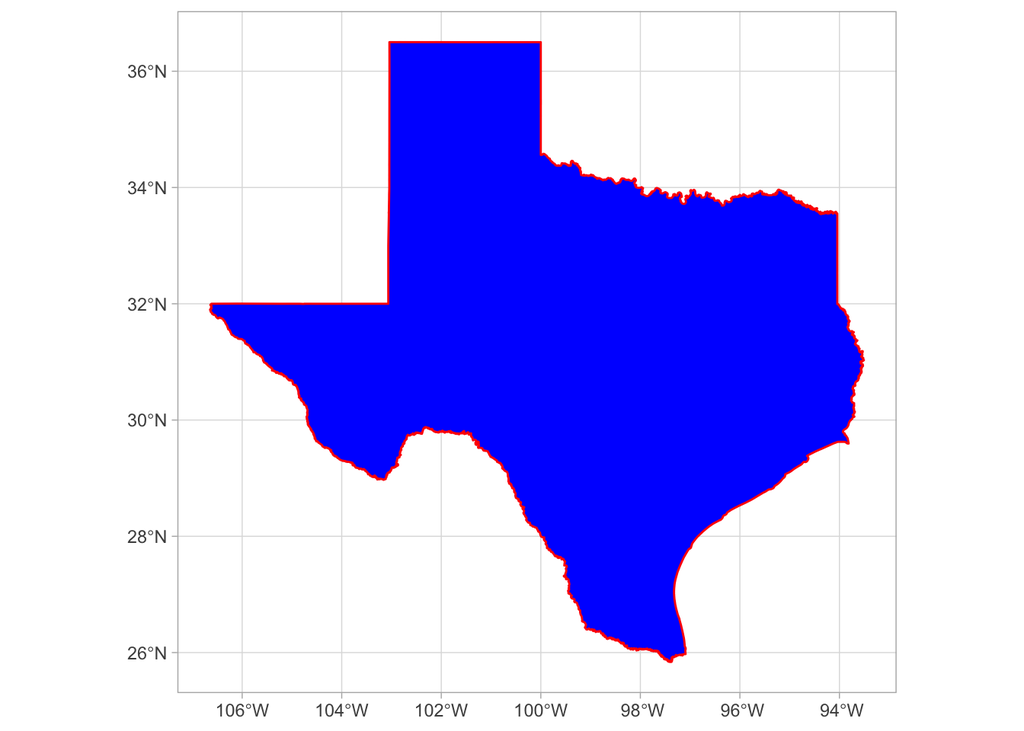

```r
start = "1985-01-01"
end   = "2015-01-01"
state = "TX"

texas = AOI::aoi_get(state = state)

# Instantiate plot
ggplot() +
  # Add texas POLYGON
  geom_sf(data = texas, color = "red", fill = "blue") +
  # Apply theme
  theme_light()
```

```r
# Query data
sites = whatNWISdata(
  # State to search
  stateCd = state,
  # Goal date range
  startDt = start, endDt = end,
  # Daily Values
  outputDataTypeCd = "dv",
  # Streamflow
  parameterCd = "00060")

glimpse(sites)
```

```
## Rows: 1,674
## Columns: 24
## $ agency_cd          <chr> "USGS", "USGS", "USGS", "USGS", "USGS", "USGS", "US…
## $ site_no            <chr> "07227420", "07227420", "07227420", "07227500", "07…
## $ station_nm         <chr> "Cramer Ck at US Hwy 54 nr Dalhart, TX", "Cramer Ck…
## $ site_tp_cd         <chr> "ST", "ST", "ST", "ST", "ST", "ST", "ST", "ST", "ST…
## $ dec_lat_va         <dbl> 35.75125, 35.75125, 35.75125, 35.47033, 35.72078, 3…
## $ dec_long_va        <dbl> -102.8932, -102.8932, -102.8932, -101.8796, -101.66…
## $ coord_acy_cd       <chr> "S", "S", "S", "F", "1", "1", "1", "F", "F", "F", "…
## $ dec_coord_datum_cd <chr> "NAD83", "NAD83", "NAD83", "NAD83", "NAD83", "NAD83…
## $ alt_va             <dbl> 3962.24, 3962.24, 3962.24, 2989.16, 2933.19, 2933.1…
## $ alt_acy_va         <dbl> 0.01, 0.01, 0.01, 0.10, 0.10, 0.10, 0.10, 0.10, 0.1…
## $ alt_datum_cd       <chr> "NGVD29", "NGVD29", "NGVD29", "NGVD29", "NAVD88", "…
## $ huc_cd             <chr> "11090102", "11090102", "11090102", "11090105", "11…
## $ data_type_cd       <chr> "dv", "dv", "dv", "dv", "dv", "dv", "dv", "dv", "dv…
## $ parm_cd            <chr> "00060", "00060", "00060", "00060", "00060", "00060…
## $ stat_cd            <chr> "00001", "00002", "00003", "00003", "00001", "00002…
## $ ts_id              <chr> "131752", "131753", "131754", "131763", "131773", "…
## $ loc_web_ds         <chr> NA, NA, NA, NA, NA, NA, NA, NA, NA, NA, NA, NA, NA,…
## $ medium_grp_cd      <chr> "wat", "wat", "wat", "wat", "wat", "wat", "wat", "w…
## $ parm_grp_cd        <chr> NA, NA, NA, NA, NA, NA, NA, NA, NA, NA, NA, NA, NA,…
## $ srs_id             <chr> "1645423", "1645423", "1645423", "1645423", "164542…
## $ access_cd          <chr> "0", "0", "0", "0", "0", "0", "0", "0", "0", "0", "…
## $ begin_date         <date> 2007-10-01, 2007-10-01, 2007-10-01, 1938-04-01, 20…
## $ end_date           <date> 2020-02-05, 2020-02-05, 2020-12-15, 2022-05-05, 20…
## $ count_nu           <dbl> 4486, 4486, 4825, 30714, 3382, 3386, 4450, 5692, 30…
```

We can see that there are 1674 streamflow gauge stations in Texas that fit our criteria. Now, let’s filter these stations a step further to include only those stations that have around 30 years of daily streamflow data with drainage area of larger than 10 km<sup>2</sup> that have been impacted by human activies.

For this we remotely access the gages 2 data set and join it to the above data.

```r
sites = read_sf('/vsizip/{/vsicurl/https://water.usgs.gov/GIS/dsdl/gagesII_9322_point_shapefile.zip}/gagesII_9322_sept30_2011.shp') |>
  # Find those that the reference classifciation is NA and the draiange area is greater then 10
  filter(is.na(HCDN_2009), DRAIN_SQKM > 10)  |>
  # Join to the site IDs returned from NWIS
  inner_join(sites, by = c("STAID" = "site_no")) |>
  # Find those that give a daily mean (stat_cd), and have at least 30 years of data
  # Send to a projected transformation
  st_transform(5070)
```

We can see that there are 1061 streamflow gauge stations in Texas that fit our criteria.

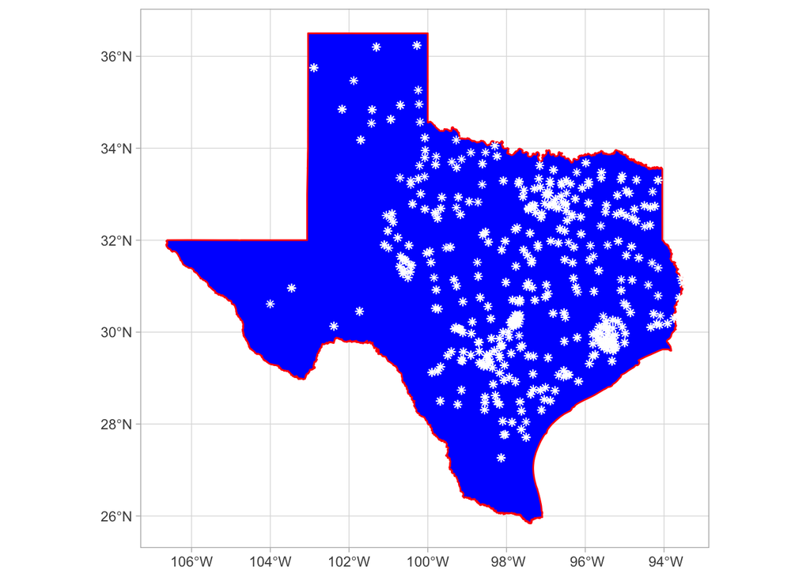

```r
# Instantiate plot
ggplot() +
  # Add texas POLYGON
  geom_sf(data = texas, color = "red", fill = "blue") +
  # Add sites to map
  geom_sf(data = sites, pch = 8, color = "white") +
  # Apply theme
  theme_light()
```

# Dams

Next we need data on dam locations and want to isolate those that are built between 1995 and 2005, are in the state of Texas, and store at least 1,000 Acre Feet.

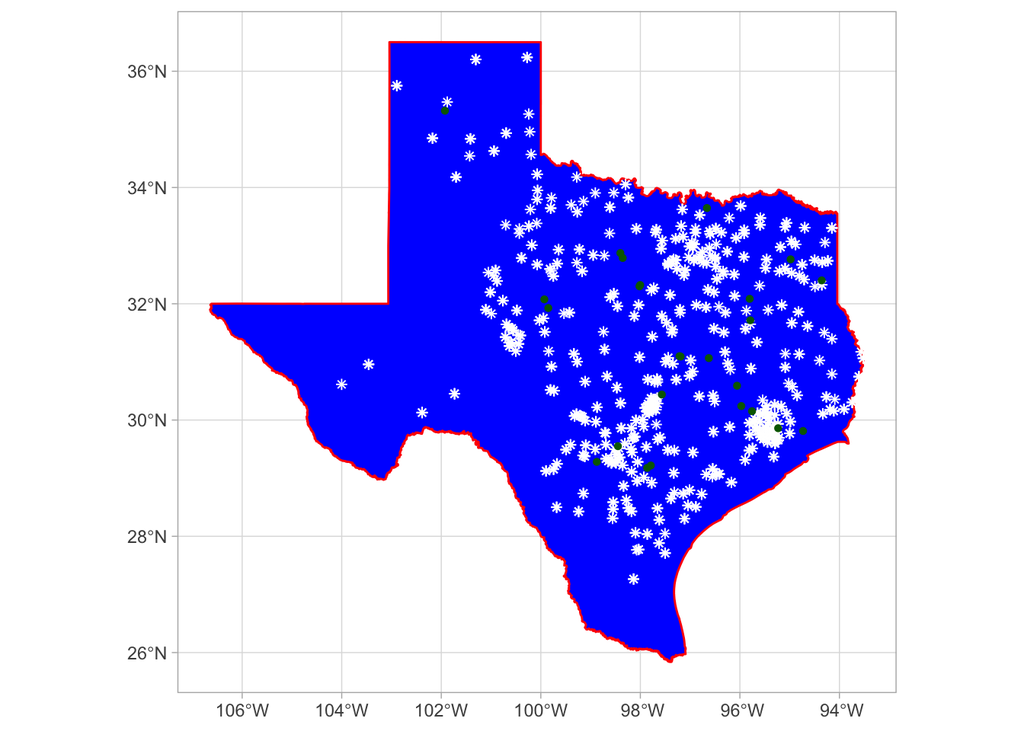

```r
# Read from USACE NID dataset
dams = read.csv('https://nid.usace.army.mil/api/nation/csv', skip = 1) %>%
  # Find those within year range, the state of Texas, and of a given size
  filter(between(Year.Completed, 1995, 2005), State == "Texas", NID.Storage..Acre.Ft. > 1000) %>%
  # convert table to sf object
  sf::st_as_sf(coords = c('Longitude', 'Latitude'), crs = 4326) |>
  # Keep only relevant columns
  select(NID.ID, NID.Storage..Acre.Ft., Year.Completed) |>
  # Send to a projected transformation
  st_transform(5070)

# Instantiate plot
ggplot() +
  # Add texas POLYGON
  geom_sf(data = texas, color = "red", fill = "blue") +
  # Add sites to map
  geom_sf(data = sites, pch = 8, color = "white") +
  # Add dams to map
  geom_sf(data = dams, pch = 16, color = "darkgreen") +
  # Apply theme
  theme_light()
```

As is evident from the plot above, there are many gage locations that don’t have any dams in their vicinity. One way to eliminate these stations is using a spatial query based on a search radius. We can determine an estimation for our search radius based on the upstream drainage area distribution of the streamflow gauges.

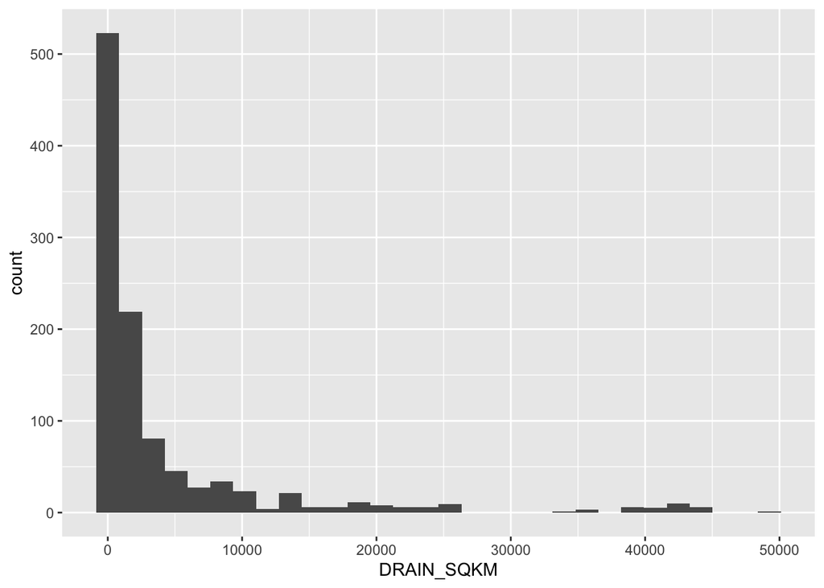

```r
# Instatiate plots, and add site data
ggplot(data = sites, aes(x = DRAIN_SQKM)) +
  # Generate a histogram
  geom_histogram()
```

We can see that most stations have a drainage area of less than 15000 km<sup>2</sup>. Since they’re not very large a search radius of 10 km should be sufficient. Now, we define a function that carries out an efficient spatial query to find the stations that have at least one dam within a 10-km radius.

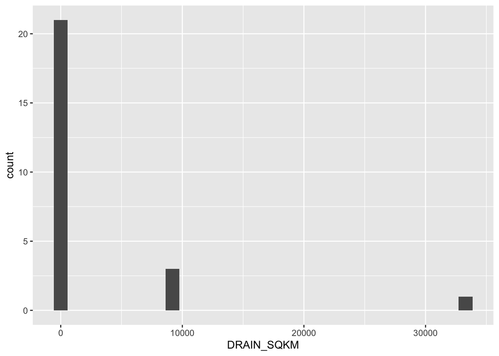

```r
# Filter the dams to only inlcude those within 10000 m of a site
dams2 = st_filter( dams, sites,
                   .predicate = st_is_within_distance,
                   dist = 10000)

# Filter the dams to only inlcude those within 10000 m of a site
sites2 = st_filter( sites, dams,
                    .predicate = st_is_within_distance,
                    dist = 10000) |>
  # Only inlcude relevant columns for readabilty
  select(STAID, DRAIN_SQKM)


# Instatiate plots, and add site data
ggplot(data = sites2, aes(x = DRAIN_SQKM)) +
  # Generate a histogram
  geom_histogram()
```

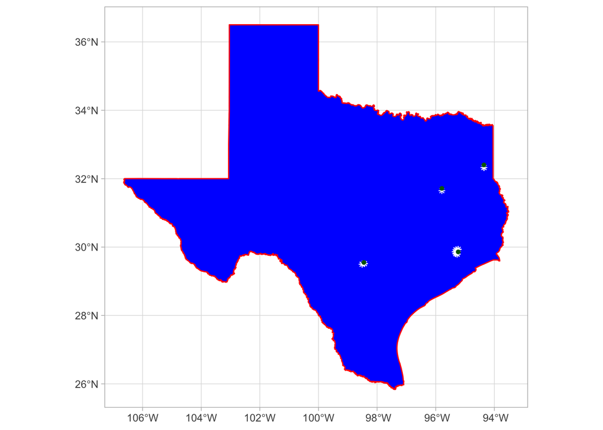

```r
# Instantiate plot
ggplot() +
  # Add texas POLYGON
  geom_sf(data = texas, color = "red", fill = "blue") +
  # Add sites to map
  geom_sf(data = sites2, pch = 8, color = "white") +
  # Add dams to map
  geom_sf(data = dams2, pch = 16, color = "darkgreen") +
  # Apply theme
  theme_light()
```

# Flowlines and Hydrolinking

```r
for(i in 1:nrow(dams2)){
  # Find the XY coordinates, in geographic space, for a dam
  pt = st_coordinates(st_transform(dams2[i,], 4326))

  # Find the COMID associated with that POINT, and add to the DAMS data.frame/sf
  dams2$dam_comid[i] = findNLDI(location = pt)$comid
}

# View Data
glimpse(dams2)
```

```
## Rows: 4
## Columns: 5
## $ NID.ID                <chr> "TX06947", "TX07211", "TX07113", "TX07214"
## $ NID.Storage..Acre.Ft. <dbl> 4684, 8741, 1633, 1063
## $ Year.Completed        <int> 1995, 2004, 2004, 2002
## $ geometry              <POINT [m]> POINT (74178.92 754083.3), POINT (-237461.5 7225…
## $ dam_comid             <chr> "1438901", "10839872", "1453665", "5278798"
```

```r
# Covert dams to data.frame, and index by the ID of the site closest to that dam
nearest = st_drop_geometry(dams2)[st_nearest_feature(sites2, dams2),]

# merge the columns of sites and nearest
joined = cbind(sites2, nearest)

# View Data
glimpse(joined)
```

```
## Rows: 25
## Columns: 7
## $ STAID                 <chr> "08022040", "08022040", "08022040", "08065000", …
## $ DRAIN_SQKM            <dbl> 9301.8760, 9301.8760, 9301.8760, 33322.2200, 23.…
## $ NID.ID                <chr> "TX07214", "TX07214", "TX07214", "TX07113", "TX0…
## $ NID.Storage..Acre.Ft. <dbl> 1063, 1063, 1063, 1633, 4684, 4684, 4684, 4684, …
## $ Year.Completed        <int> 2002, 2002, 2002, 2004, 1995, 1995, 1995, 1995, …
## $ dam_comid             <chr> "5278798", "5278798", "5278798", "1453665", "143…
## $ geometry              <POINT [m]> POINT (154198.2 1029604), POINT (154198.2 …
```

```r
for(i in 1:nrow(joined)){
  # Use the NLDI to find the upstream COMID (w/in 10km) of each gage site
  tmp = findNLDI(nwis = joined$STAID[i], nav = "UT", distance_km = 10)

  # Check if the linked dam COMID is in the uptream COMIDs for each gage
  joined$upstream[i] = joined$dam_comid[i] %in% tmp$UT_flowlines$nhdplus_comid
}

# Only keep those in which the large dam is upstream
joined = filter(joined, upstream)

glimpse(joined)
```

```
## Rows: 3
## Columns: 8
## $ STAID                 <chr> "08178700", "08178700", "08178700"
## $ DRAIN_SQKM            <dbl> 349.7931, 349.7931, 349.7931
## $ NID.ID                <chr> "TX07211", "TX07211", "TX07211"
## $ NID.Storage..Acre.Ft. <dbl> 8741, 8741, 8741
## $ Year.Completed        <int> 2004, 2004, 2004
## $ dam_comid             <chr> "10839872", "10839872", "10839872"
## $ geometry              <POINT [m]> POINT (-235666.1 718715.7), POINT (-235666.1 718…
## $ upstream              <lgl> TRUE, TRUE, TRUE
```

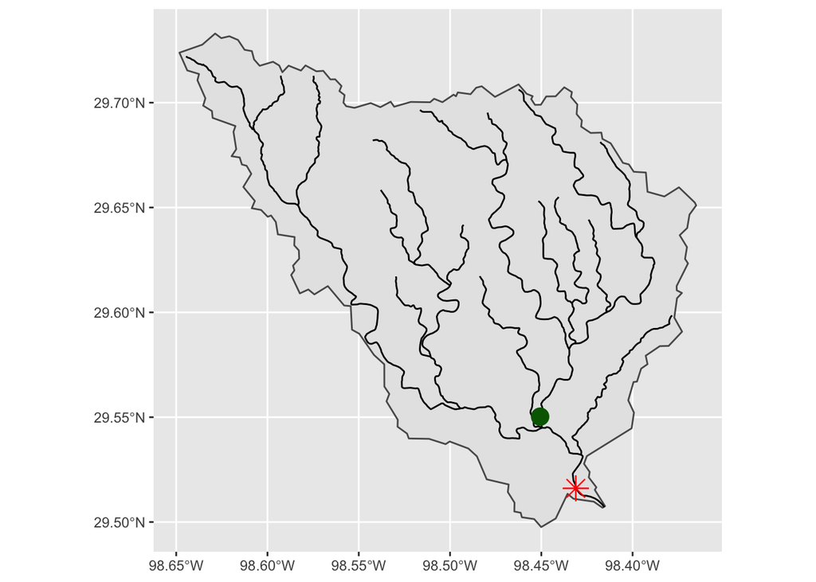

```r
tmp = findNLDI(nwis = joined$STAID[1],
               nav = "UT",
               find= c('flowlines', "basin"))

ggplot() +
  geom_sf(data = tmp$basin) +
  geom_sf(data = tmp$UT_flowlines) +
  geom_sf(data = joined, pch = 8, color = "red", cex = 5) +
  geom_sf(data = filter(dams2, NID.ID %in% joined$NID.ID), pch = 16, color = "darkgreen", cex = 5)
```

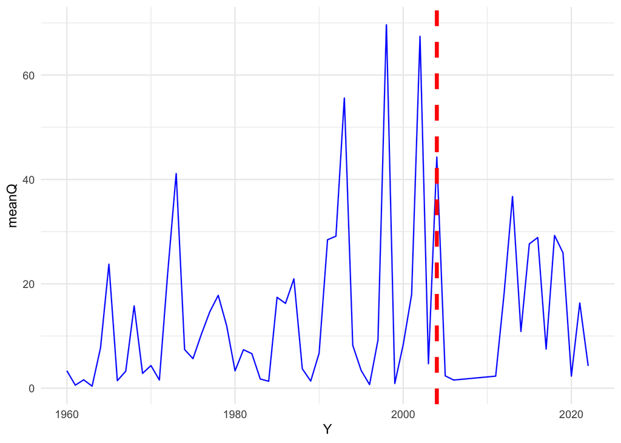

```r
flows = readNWISdv(siteNumbers = joined$STAID,
                   parameterCd = "00060") |>
  renameNWISColumns() |>
  mutate(Y = as.numeric(format(Date, "%Y"))) |>
  group_by(Y) |>
  summarize(meanQ  = mean(Flow))


ggplot(data = flows, aes(x = Y, y = meanQ )) +
  geom_line(color = "blue") +
  geom_vline(xintercept =  2004, lty = 2, color = 'red', lwd = 1.5) +
  theme_minimal()
```

```r
r = rast("/vsicurl/https://storage.googleapis.com/feddata-r/nlcd/2019_Land_Cover_L48.tif")

vAOI = project(vect(tmp$basin), crs(r))

lc = crop(r, vAOI, snap = "out") |>
  mask(vAOI)


freq(lc) |>
  arrange(-count) |>
  mutate(sqkm = count * prod(res(lc)) /1e6)
```

```
##    layer                        value count    sqkm
## 1      1             Evergreen Forest 99002 89.1018
## 2      1  Developed, Medium Intensity 83564 75.2076
## 3      1     Developed, Low Intensity 68644 61.7796
## 4      1        Developed, Open Space 53876 48.4884
## 5      1                  Shrub/Scrub 47417 42.6753
## 6      1    Developed, High Intensity 32389 29.1501
## 7      1             Deciduous Forest  7751  6.9759
## 8      1                  Barren Land  6828  6.1452
## 9      1                   Herbaceous  3690  3.3210
## 10     1               Woody Wetlands  2561  2.3049
## 11     1                   Open Water   563  0.5067
## 12     1                 Mixed Forest   541  0.4869
## 13     1                  Hay/Pasture    39  0.0351
## 14     1 Emergent Herbaceous Wetlands    31  0.0279
## 15     1             Cultivated Crops    27  0.0243
```